# Sentiment analysis: Climate-related speeches by danish prime ministers Anders Fogh and Mette Frederiksen

### NRC lexicon for sentiment analysis

With the NRC lexicon I can “bin” the words of the text by the feelings they’re typically associated with. As above, I use inner_join() to combine the fogh1 non-stopword text with the nrc lexicon:

```r
fogh1_nrc <- fogh1_stop %>%
  inner_join(get_sentiments("nrc"))
```

I then check which are excluded using `anti_join()`:

```r
fogh1_exclude <- fogh1_stop %>%
  anti_join(get_sentiments("nrc"))

View(fogh1_exclude)

# Counting words to find the most excluded:
fogh1_exclude_n <- fogh1_exclude %>%
  count(word, sort = TRUE)

head(fogh1_exclude_n)
```

```
## # A tibble: 6 × 2
##   word           n
##   <chr>      <int>
## 1 climate       36
## 2 danish        28
## 3 energy        27
## 4 chinese       26
## 5 anders        23
## 6 conference    23
```

Now I find some counts by sentiment and word, and then facet them:

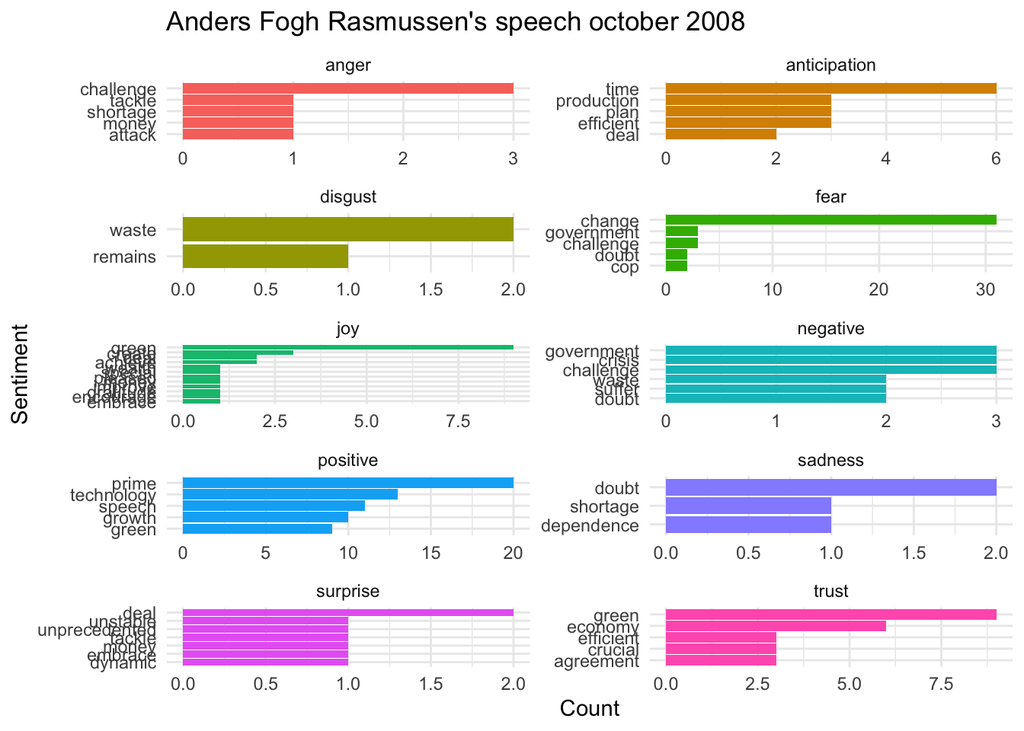

```r
fogh1_nrc_n5 <- fogh1_nrc %>%
  count(word,sentiment, sort = TRUE) %>%
  group_by(sentiment) %>%
  top_n(5) %>%
  ungroup()

fogh1_nrc_gg <- ggplot(data = fogh1_nrc_n5, aes(x = reorder(word,n), y = n, fill = sentiment)) +
  geom_col(show.legend = FALSE) +
  facet_wrap(~sentiment, ncol = 2, scales = "free") +
  coord_flip() +
  theme_minimal() +
  labs(title = "Anders Fogh Rasmussen's speech october 2008",
       x = "Sentiment", y = "Count")

# Show it
fogh1_nrc_gg
```

```r
# Save it
ggsave(plot = fogh1_nrc_gg,
       here("figures","fogh1_nrc_sentiment.png"),
       height = 8,
       width = 5)
```

It seems that the word “government” shows up in NRC lexicon as “fear”. I check:

```r
gov <- get_sentiments(lexicon = "nrc") %>%
  filter(word == "government")

# Indeed, the word government belongs to the sentiments 'fear' and 'negative' in the NRC lexicon:
gov
```

```
## # A tibble: 2 × 2
##   word       sentiment
##   <chr>      <chr>
## 1 government fear
## 2 government negative
```

### SPEECH NUMBER TWO (‘fogh2’)

“Prime Minister Anders Fogh Rasmussen, at the UN Climate Change Conference in Poznan, Poland at December 1, 2008”

#Get the second speech:

```r
fogh2_path <- here("data","fogh2.pdf")
fogh2_text <- pdf_text(fogh2_path)
```

### Some wrangling:

- Here I split up the pages into separate lines (separated by `\n`) using `stringr::str_split()`
- Unnest into regular columns using `tidyr::unnest()`
- Remove leading/trailing white space with `stringr::str_trim()`

```r
fogh2_df <- data.frame(fogh2_text) %>%
  mutate(text_full = str_split(fogh2_text, pattern = '\n')) %>%
  unnest(text_full) %>%
  mutate(text_full = str_trim(text_full))
```

Now each line, on each page, is its own row, with extra starting & trailing spaces removed.

### Get the tokens (individual words) in tidy format

Here I use `tidytext::unnest_tokens()` (which pulls from the `tokenizer`) package, to split columns into tokens. I am interested in *words*, so that’s the token we’ll use:

```r
fogh2_tokens <- fogh2_df %>%
  unnest_tokens(word, text_full)
```

Then I count the words

```r
fogh2_wc <- fogh2_tokens %>%
  count(word) %>%
  arrange(-n)
fogh2_wc
```

```
## # A tibble: 365 × 2
##    word        n
##    <chr>   <int>
##  1 the        46
##  2 to         31
##  3 and        28
##  4 a          24
##  5 climate    22
##  6 in         22
##  7 at         21
##  8 change     19
##  9 by         15
## 10 is         15
## # ℹ 355 more rows
```

At this point I notice that a whole bunch of things show up frequently that we might not be interested in (“the”, “and”, “to”, etc.). These are called *stop words*. I will remove them.

### Remove stop words:

I remove stop words using `tidyr::anti_join()`:

```r
fogh2_stop <- fogh2_tokens %>%
  anti_join(stop_words) %>%
  select(-fogh2_text)
```

And then check the counts again:

```r
fogh2_swc <- fogh2_stop %>%
  count(word) %>%
  arrange(-n)
fogh2_swc
```

```
## # A tibble: 258 × 2
##    word         n
##    <chr>    <int>
##  1 climate     22
##  2 change      19
##  3 1           14
##  4 address     13
##  5 global      13
##  6 minister    13
##  7 poland      13
##  8 poznan      13
##  9 prime       13
## 10 2008        12
## # ℹ 248 more rows
```

Since I am interested in the words, I now want to get rid of all the numbers (non-text) in `fogh2_stop`

```r
fogh2_no_numeric <- fogh2_stop %>%
  filter(is.na(as.numeric(word)))
```

```r
length(unique(fogh2_no_numeric$word))
```

```
## [1] 244
```

```r
# I filter the wordcloud to only include the top 100 most frequent words

fogh2_top100 <- fogh2_no_numeric %>%
  count(word) %>%
  arrange(-n) %>%
  head(100)
fogh2_top100
```

```
## # A tibble: 100 × 2
##    word         n
##    <chr>    <int>
##  1 climate     22
##  2 change      19
##  3 address     13
##  4 global      13
##  5 minister    13
##  6 poland      13
##  7 poznan      13
##  8 prime       13
##  9 december    12
## 10 anders      10
## # ℹ 90 more rows
```

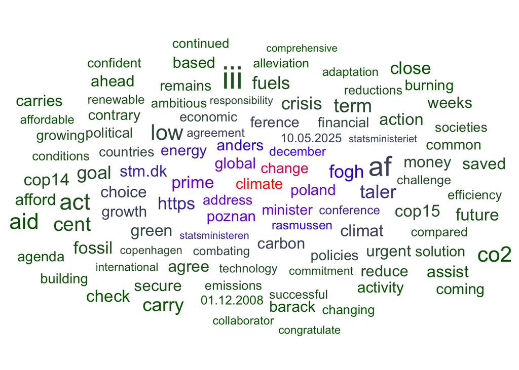

```r
fogh2_cloud <- ggplot(data = fogh2_top100, aes(label = word)) +
  geom_text_wordcloud_area(aes(color = n), shape = "pentagram") +
  scale_size_area(max_size = 12) +
  scale_color_gradientn(colors = c("darkgreen","blue","red")) +
  theme_minimal()


# Save it
ggsave(plot = fogh2_cloud,
       here("figures","fogh2_wordcloud.png"),
       height = 8,
       width = 5)

fogh2_cloud
```

### Sentiment analysis

- AFINN from Finn Årup Nielsen,
- nrc from Saif Mohammad and Peter Turney

The AFINN lexicon assigns words with a score that runs between -5 and 5, with negative scores indicating negative sentiment and positive scores indicating positive sentiment.

The nrc lexicon categorizes words in a binary fashion (“yes”/“no”) into categories of positive, negative, anger, anticipation, disgust, fear, joy, sadness, surprise, and trust.

### Sentiment analysis with afinn:

First I bind the words in `fogh2_stop` to `afinn` lexicon:

```r
fogh2_afinn <- fogh2_stop %>%
  inner_join(get_sentiments("afinn"))
fogh2_afinn
```

```
## # A tibble: 56 × 2
##    word         value
##    <chr>        <dbl>
##  1 congratulate     2
##  2 successful       3
##  3 crisis          -3
##  4 negative        -2
##  5 resolve          2
##  6 confident        2
##  7 crisis          -3
##  8 stronger         2
##  9 crisis          -3
## 10 prevent         -1
## # ℹ 46 more rows
```

Then I find some counts (by sentiment ranking):

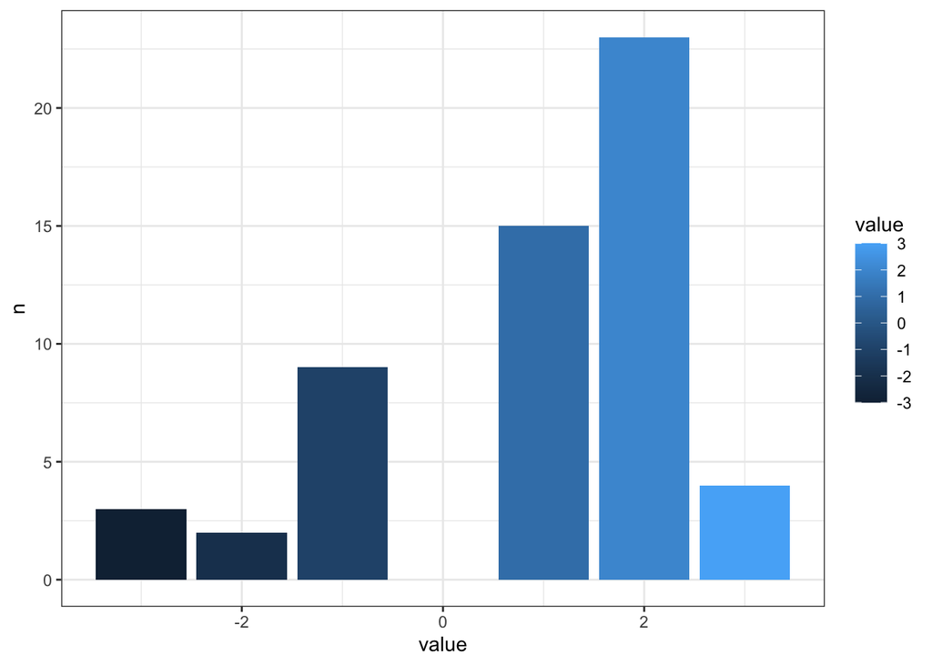

```r
fogh2_afinn_hist <- fogh2_afinn %>%
  count(value)

# And plot them:
ggplot(data = fogh2_afinn_hist, aes(x = value, y = n)) +
  geom_col(aes(fill = value)) +
  theme_bw()
```

I want to investigate some of the words in a bit more depth:

```r
# I want to know what these '2' words are
fogh2_afinn2 <- fogh2_afinn %>%
  filter(value == 2)

fogh2_afinn2
```

```
## # A tibble: 23 × 2
##    word         value
##    <chr>        <dbl>
##  1 congratulate     2
##  2 resolve          2
##  3 confident        2
##  4 stronger         2
##  5 commitment       2
##  6 secure           2
##  7 stable           2
##  8 improve          2
##  9 growth           2
## 10 ambitious        2
## # ℹ 13 more rows
```

```r
# I check the unique 2-score words:
unique(fogh2_afinn2$word)
```

```
##  [1] "congratulate"  "resolve"       "confident"     "stronger"
##  [5] "commitment"    "secure"        "stable"        "improve"
##  [9] "growth"        "ambitious"     "saved"         "gained"
## [13] "comprehensive" "responsible"   "progress"
```

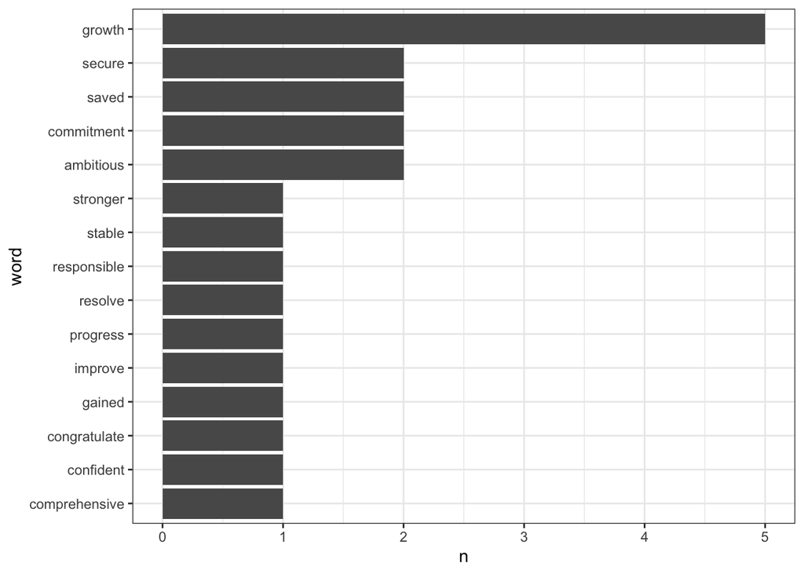

```r
# Then count & plot them:
fogh2_afinn2_n <- fogh2_afinn2 %>%
  count(word, sort = TRUE) %>%
  mutate(word = fct_reorder(factor(word), n))


ggplot(data = fogh2_afinn2_n, aes(x = word, y = n)) +
  geom_col() +
  coord_flip() +
  theme_bw()
```

```r
# So, as with the first speech from the earlier period of my study ('fogh1'+'fogh2'), the 2-score word 'growth' is used most often.
```

Summary of the sentiment of the speech, fogh2:

```r
fogh2_summary <- fogh2_afinn %>%
  summarize(
    mean_score = mean(value),
    median_score = median(value)
  )
fogh2_summary
```

```
## # A tibble: 1 × 2
##   mean_score median_score
##        <dbl>        <dbl>
## 1      0.911            1
```

```r
# mean score of 0,91 and median score of 1 tells me that the second speech, fogh2, is positive in terms of the sentiment.
```

### NRC lexicon for sentiment analysis

With the NRC lexicon I can “bin” the words of the text by the feelings they’re typically associated with. As above, I use inner_join() to combine the fogh2 non-stopword text with the nrc lexicon:

```r
fogh2_nrc <- fogh2_stop %>%
  inner_join(get_sentiments("nrc"))
```

I then check which are excluded using `anti_join()`:

```r
fogh2_exclude <- fogh2_stop %>%
  anti_join(get_sentiments("nrc"))

View(fogh2_exclude)

# Counting words to find the most excluded:
fogh2_exclude_n <- fogh2_exclude %>%
  count(word, sort = TRUE)

head(fogh2_exclude_n)
```

```
## # A tibble: 6 × 2
##   word         n
##   <chr>    <int>
## 1 climate     22
## 2 1           14
## 3 address     13
## 4 global      13
## 5 minister    13
## 6 poland      13
```

Now I find some counts by sentiment and word, and then facet them:

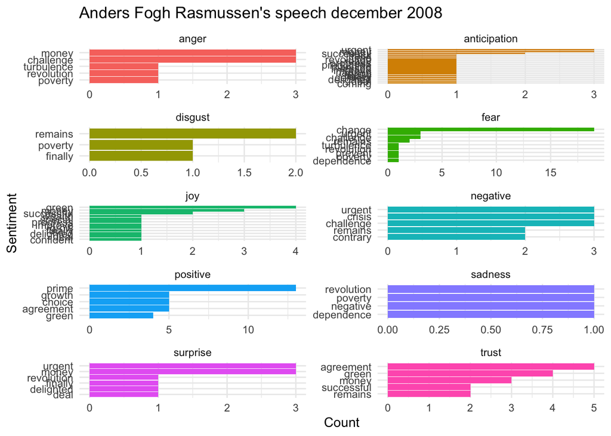

```r
fogh2_nrc_n5 <- fogh2_nrc %>%
  count(word,sentiment, sort = TRUE) %>%
  group_by(sentiment) %>%
  top_n(5) %>%
  ungroup()

fogh2_nrc_gg <- ggplot(data = fogh2_nrc_n5, aes(x = reorder(word,n), y = n, fill = sentiment)) +
  geom_col(show.legend = FALSE) +
  facet_wrap(~sentiment, ncol = 2, scales = "free") +
  coord_flip() +
  theme_minimal() +
  labs(title = "Anders Fogh Rasmussen's speech december 2008",
       x = "Sentiment", y = "Count")

# Show it
fogh2_nrc_gg
```

```r
# Save it
ggsave(plot = fogh2_nrc_gg,
       here("figures","fogh2_nrc_sentiment.png"),
       height = 8,
       width = 5)
```

It seems that the word “change” shows up in NRC lexicon as “fear”. I check:

```r
chg <- get_sentiments(lexicon = "nrc") %>%
  filter(word == "change")

# Indeed, the word 'change' belongs to the sentiments 'fear' in the NRC lexicon:
chg
```

```
## # A tibble: 1 × 2
##   word   sentiment
##   <chr>  <chr>
## 1 change fear
```

### SPEECH NUMBER THREE (‘frederiksen1’)

“Statsministerens tale ved C40 i København den 11. oktober 2019”

#Get the third speech:

```r
frederiksen1_path <- here("data","frederiksen1.pdf")
frederiksen1_text <- pdf_text(frederiksen1_path)
```

### Some wrangling:

- Here I split up the pages into separate lines (separated by `\n`) using `stringr::str_split()`
- Unnest into regular columns using `tidyr::unnest()`
- Remove leading/trailing white space with `stringr::str_trim()`

```r
frederiksen1_df <- data.frame(frederiksen1_text) %>%
  mutate(text_full = str_split(frederiksen1_text, pattern = '\n')) %>%
  unnest(text_full) %>%
  mutate(text_full = str_trim(text_full))
```

Now each line, on each page, is its own row, with extra starting & trailing spaces removed.

### Get the tokens (individual words) in tidy format

Here I use `tidytext::unnest_tokens()` (which pulls from the `tokenizer`) package, to split columns into tokens. I am interested in *words*, so that’s the token we’ll use:

```r
frederiksen1_tokens <- frederiksen1_df %>%
  unnest_tokens(word, text_full)
```

Then I count the words

```r
frederiksen1_wc <- frederiksen1_tokens %>%
  count(word) %>%
  arrange(-n)
frederiksen1_wc
```

```
## # A tibble: 402 × 2
##    word      n
##    <chr> <int>
##  1 the      51
##  2 to       34
##  3 of       32
##  4 i        29
##  5 and      26
##  6 is       24
##  7 we       24
##  8 2019     16
##  9 a        15
## 10 in       15
## # ℹ 392 more rows
```

At this point I notice that a whole bunch of things show up frequently that we might not be interested in (“the”, “of”, “to”, etc.). These are called *stop words*. I will remove them.

### Remove stop words:

I remove stop words using `tidyr::anti_join()`:

```r
frederiksen1_stop <- frederiksen1_tokens %>%
  anti_join(stop_words) %>%
  select(-frederiksen1_text)
```

And then check the counts again:

```r
frederiksen1_swc <- frederiksen1_stop %>%
  count(word) %>%
  arrange(-n)
frederiksen1_swc
```

```
## # A tibble: 235 × 2
##    word                 n
##    <chr>            <int>
##  1 2019                16
##  2 tale                15
##  3 11                  14
##  4 c40                 14
##  5 den                 14
##  6 oktober             14
##  7 statsministerens    14
##  8 ved                 14
##  9 https                9
## 10 statsministeren      9
## # ℹ 225 more rows
```

Since I am interested in the words, I now want to get rid of all the numbers (non-text) in `frederiksen1_stop`

```r
frederiksen1_no_numeric <- frederiksen1_stop %>%
  filter(is.na(as.numeric(word)))
```

```r
length(unique(frederiksen1_no_numeric$word))
```

```
## [1] 219
```

```r
# I filter the wordcloud to only include the top 100 most frequent words

frederiksen1_top100 <- frederiksen1_no_numeric %>%
  count(word) %>%
  arrange(-n) %>%
  head(100)
frederiksen1_top100
```

```
## # A tibble: 100 × 2
##    word                 n
##    <chr>            <int>
##  1 tale                15
##  2 c40                 14
##  3 den                 14
##  4 oktober             14
##  5 statsministerens    14
##  6 ved                 14
##  7 https                9
##  8 statsministeren      9
##  9 stm.dk               9
## 10 københavn            8
## # ℹ 90 more rows
```

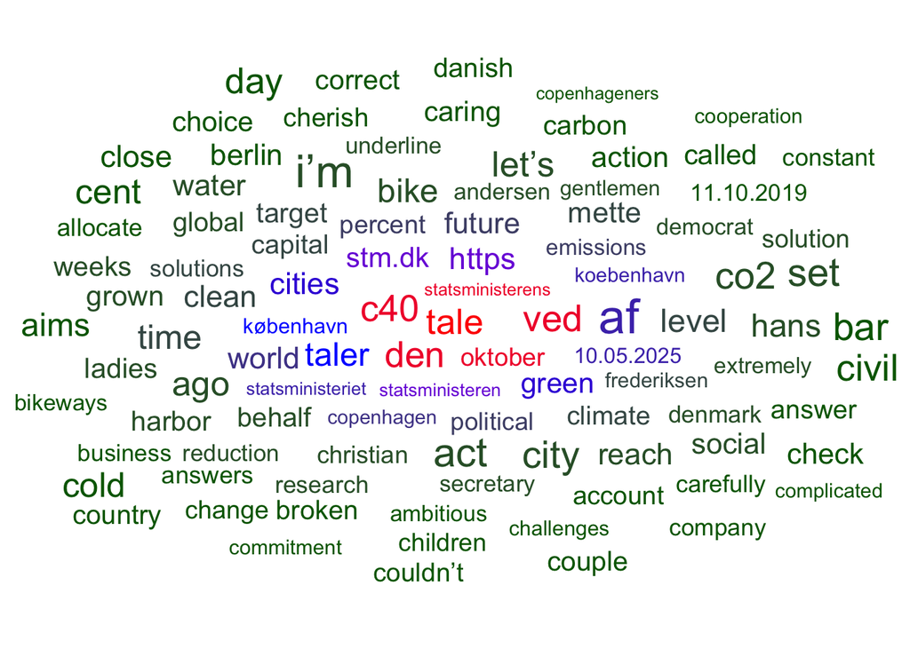

```r
frederiksen1_cloud <- ggplot(data = frederiksen1_top100, aes(label = word)) +
  geom_text_wordcloud_area(aes(color = n), shape = "pentagram") +
  scale_size_area(max_size = 12) +
  scale_color_gradientn(colors = c("darkgreen","blue","red")) +
  theme_minimal()


# Save it
ggsave(plot = frederiksen1_cloud,
       here("figures","frederiksen1_wordcloud.png"),
       height = 8,
       width = 5)

frederiksen1_cloud
```

### Sentiment analysis

- AFINN from Finn Årup Nielsen,
- nrc from Saif Mohammad and Peter Turney

The AFINN lexicon assigns words with a score that runs between -5 and 5, with negative scores indicating negative sentiment and positive scores indicating positive sentiment.

The nrc lexicon categorizes words in a binary fashion (“yes”/“no”) into categories of positive, negative, anger, anticipation, disgust, fear, joy, sadness, surprise, and trust.

### Sentiment analysis with afinn:

First I bind the words in `frederiksen1_stop` to `afinn` lexicon:

```r
frederiksen1_afinn <- frederiksen1_stop %>%
  inner_join(get_sentiments("afinn"))
frederiksen1_afinn
```

```
## # A tibble: 31 × 2
##    word      value
##    <chr>     <dbl>
##  1 grateful      3
##  2 solution      1
##  3 solution      1
##  4 happy         3
##  5 solutions     1
##  6 clean         2
##  7 clean         2
##  8 clean         2
##  9 progress      2
## 10 broken       -1
## # ℹ 21 more rows
```

Then I find some counts (by sentiment ranking):

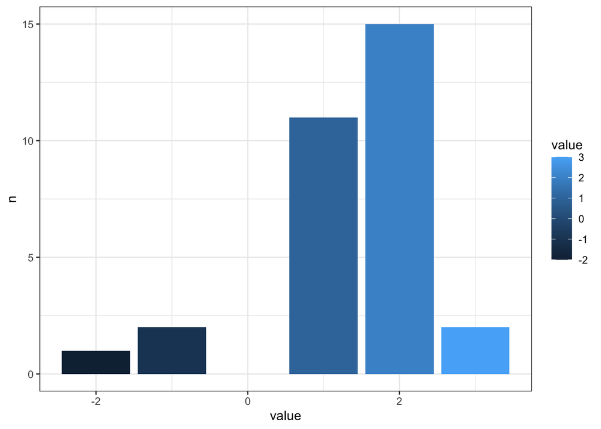

```r
frederiksen1_afinn_hist <- frederiksen1_afinn %>%
  count(value)

# And plot them:
ggplot(data = frederiksen1_afinn_hist, aes(x = value, y = n)) +
  geom_col(aes(fill = value)) +
  theme_bw()
```

I want to investigate some of the words in a bit more depth:

```r
# I want to know what these '2' words are
frederiksen1_afinn2 <- frederiksen1_afinn %>%
  filter(value == 2)
```

```r
# I check the unique 2-score words:
unique(frederiksen1_afinn2$word)
```

```
##  [1] "clean"      "progress"   "proud"      "honest"     "ambitious"
##  [6] "strong"     "carefully"  "cherish"    "commitment" "encourage"
## [11] "improve"    "sunshine"   "freedom"
```

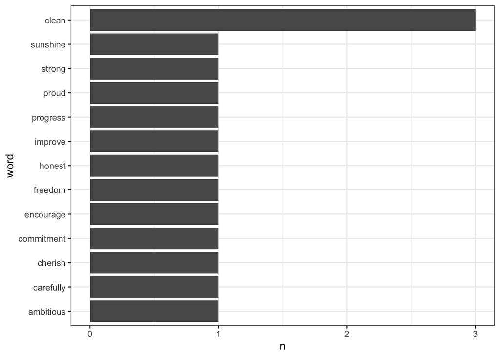

```r
# Then count & plot them:
frederiksen1_afinn2_n <- frederiksen1_afinn2 %>%
  count(word, sort = TRUE) %>%
  mutate(word = fct_reorder(factor(word), n))


ggplot(data = frederiksen1_afinn2_n, aes(x = word, y = n)) +
  geom_col() +
  coord_flip() +
  theme_bw()
```

```r
# So, of the 2-score words 'clean' is used far more often.
```

Summary of the sentiment of the speech, frederiksen1:

```r
frederiksen1_summary <- frederiksen1_afinn %>%
  summarize(
    mean_score = mean(value),
    median_score = median(value)
  )
frederiksen1_summary
```

```
## # A tibble: 1 × 2
##   mean_score median_score
##        <dbl>        <dbl>
## 1       1.39            2
```

```r
# mean score of 1,39 and median score of 2 tells me that the third speech, frederiksen1, is overall rather positive in terms of the sentiment.
```

### NRC lexicon for sentiment analysis

With the NRC lexicon I can “bin” the words of the text by the feelings they’re typically associated with. As above, I use inner_join() to combine the frederiksen1 non-stopword text with the nrc lexicon:

```r
frederiksen1_nrc <- frederiksen1_stop %>%
  inner_join(get_sentiments("nrc"))
```

I then check which are excluded using `anti_join()`:

```r
frederiksen1_exclude <- frederiksen1_stop %>%
  anti_join(get_sentiments("nrc"))

View(frederiksen1_exclude)

# Counting words to find the most excluded:
frederiksen1_exclude_n <- frederiksen1_exclude %>%
  count(word, sort = TRUE)

head(frederiksen1_exclude_n)
```

```
## # A tibble: 6 × 2
##   word                 n
##   <chr>            <int>
## 1 2019                16
## 2 11                  14
## 3 c40                 14
## 4 den                 14
## 5 oktober             14
## 6 statsministerens    14
```

Now I find some counts by sentiment and word, and then facet them:

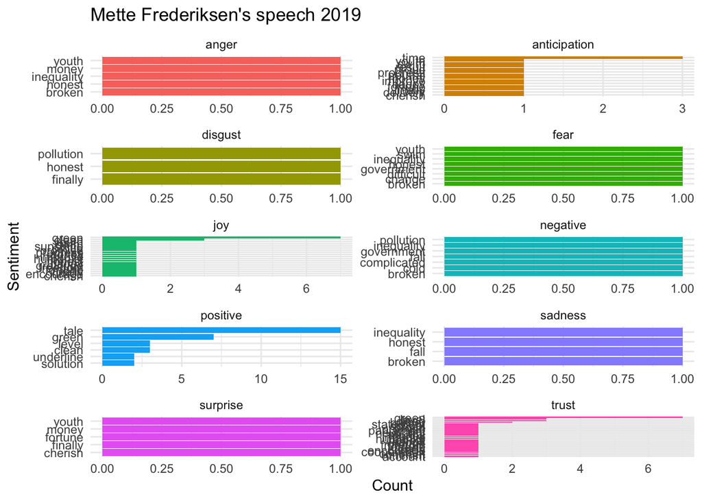

```r
frederiksen1_nrc_n5 <- frederiksen1_nrc %>%
  count(word,sentiment, sort = TRUE) %>%
  group_by(sentiment) %>%
  top_n(5) %>%
  ungroup()

frederiksen1_nrc_gg <- ggplot(data = frederiksen1_nrc_n5, aes(x = reorder(word,n), y = n, fill = sentiment)) +
  geom_col(show.legend = FALSE) +
  facet_wrap(~sentiment, ncol = 2, scales = "free") +
  coord_flip() +
  theme_minimal() +
  labs(title = "Mette Frederiksen's speech 2019",
       x = "Sentiment", y = "Count")

# Show it
frederiksen1_nrc_gg
```

```r
# Save it
ggsave(plot = frederiksen1_nrc_gg,
       here("figures","frederiksen1_nrc_sentiment.png"),
       height = 8,
       width = 5)
```

It seems that the word “green” shows up in NRC lexicon as “joy”, “positive” and “trust”. I check:

```r
green <- get_sentiments(lexicon = "nrc") %>%
  filter(word == "green")

# Indeed, the word "green" belongs to the sentiments 'joy', 'positive' and 'trust' in the NRC lexicon:
green
```

```
## # A tibble: 3 × 2
##   word  sentiment
##   <chr> <chr>
## 1 green joy
## 2 green positive
## 3 green trust
```

### SPEECH NUMBER FOUR (‘frederiksen2’)

“Statsminister Mette Frederiksens tale ved Leaders Summit on Climate den 23. april 2021”

#Get the fourth speech:

```r
frederiksen2_path <- here("data","frederiksen2.pdf")
frederiksen2_text <- pdf_text(frederiksen2_path)
```

### Some wrangling:

- Here I split up the pages into separate lines (separated by `\n`) using `stringr::str_split()`
- Unnest into regular columns using `tidyr::unnest()`
- Remove leading/trailing white space with `stringr::str_trim()`

```r
frederiksen2_df <- data.frame(frederiksen2_text) %>%
  mutate(text_full = str_split(frederiksen2_text, pattern = '\n')) %>%
  unnest(text_full) %>%
  mutate(text_full = str_trim(text_full))
```

Now each line, on each page, is its own row, with extra starting & trailing spaces removed.

### Get the tokens (individual words) in tidy format

Here I use `tidytext::unnest_tokens()` (which pulls from the `tokenizer`) package, to split columns into tokens. I am interested in *words*, so that’s the token we’ll use:

```r
frederiksen2_tokens <- frederiksen2_df %>%
  unnest_tokens(word, text_full)
```

Then I count the words

```r
frederiksen2_wc <- frederiksen2_tokens %>%
  count(word) %>%
  arrange(-n)
frederiksen2_wc
```

```
## # A tibble: 234 × 2
##    word        n
##    <chr>   <int>
##  1 mette      13
##  2 on         13
##  3 the        13
##  4 climate    12
##  5 in         12
##  6 tale       11
##  7 2021       10
##  8 23         10
##  9 and        10
## 10 april      10
## # ℹ 224 more rows
```

### Remove stop words:

I remove stop words using `tidyr::anti_join()`:

```r
frederiksen2_stop <- frederiksen2_tokens %>%
  anti_join(stop_words) %>%
  select(-frederiksen2_text)
```

And then check the counts again:

```r
frederiksen2_swc <- frederiksen2_stop %>%
  count(word) %>%
  arrange(-n)
frederiksen2_swc
```

```
## # A tibble: 154 × 2
##    word              n
##    <chr>         <int>
##  1 mette            13
##  2 climate          12
##  3 tale             11
##  4 2021             10
##  5 23               10
##  6 april            10
##  7 den              10
##  8 frederiksens     10
##  9 leaders          10
## 10 statsminister    10
## # ℹ 144 more rows
```

Since I am interested in the words, I now want to get rid of all the numbers (non-text) in `frederiksen2_stop`

```r
frederiksen2_no_numeric <- frederiksen2_stop %>%
  filter(is.na(as.numeric(word)))
```

```r
length(unique(frederiksen2_no_numeric$word))
```

```
## [1] 142
```

```r
# I filter the wordcloud to only include the top 100 most frequent words

frederiksen2_top100 <- frederiksen2_no_numeric %>%
  count(word) %>%
  arrange(-n) %>%
  head(100)
frederiksen2_top100
```

```
## # A tibble: 100 × 2
##    word              n
##    <chr>         <int>
##  1 mette            13
##  2 climate          12
##  3 tale             11
##  4 april            10
##  5 den              10
##  6 frederiksens     10
##  7 leaders          10
##  8 statsminister    10
##  9 summit           10
## 10 ved              10
## # ℹ 90 more rows
```

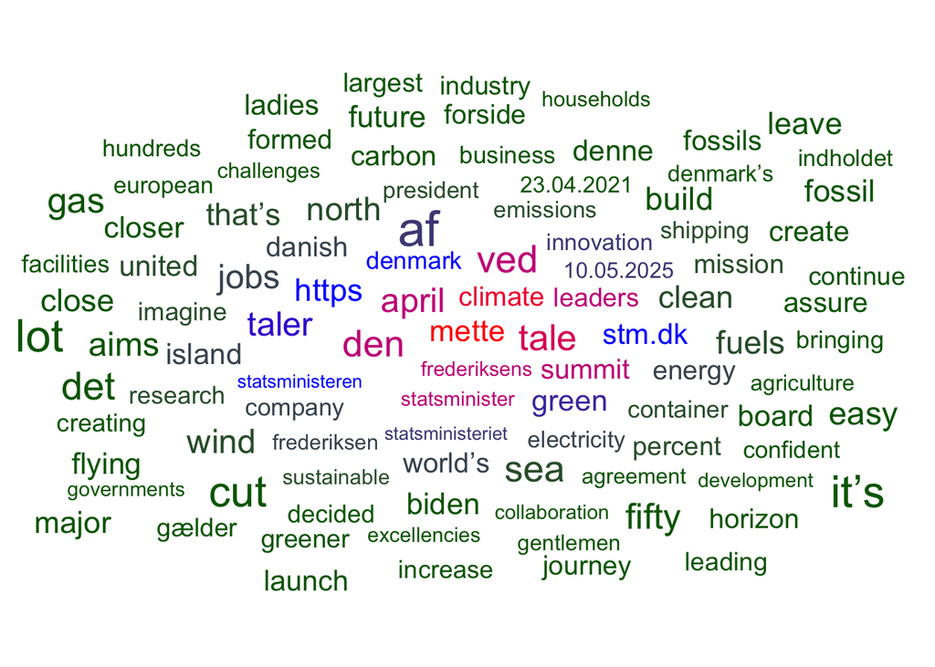

```r
frederiksen2_cloud <- ggplot(data = frederiksen2_top100, aes(label = word)) +
  geom_text_wordcloud_area(aes(color = n), shape = "pentagram") +
  scale_size_area(max_size = 12) +
  scale_color_gradientn(colors = c("darkgreen","blue","red")) +
  theme_minimal()


# Save it
ggsave(plot = frederiksen2_cloud,
       here("figures","frederiksen2_wordcloud.png"),
       height = 8,
       width = 5)

frederiksen2_cloud
```

### Sentiment analysis

- AFINN from Finn Årup Nielsen,
- nrc from Saif Mohammad and Peter Turney

The AFINN lexicon assigns words with a score that runs between -5 and 5, with negative scores indicating negative sentiment and positive scores indicating positive sentiment.

The nrc lexicon categorizes words in a binary fashion (“yes”/“no”) into categories of positive, negative, anger, anticipation, disgust, fear, joy, sadness, surprise, and trust.